# ggmitji

2022-05-30

**[Adrià Mitjavila](https://amitjavilaventura.github.io)** on *May 20, 2022*

Look at the source code [here](https://github.com/amitjavilaventura/ggmitji).

Look at the documentation [here](https://amitjavilaventura.github.io/ggmitji/).

*ggmitji* is an R package with cool functions to complement ggplots.

## Dependencies

`ggmitji` depends on several packages, such as: `ggplot2`, `magrittr`, `polyclip`, `cowplot`, and `ggpubr`.

## Functions

### Boxplots

#### without outliers

If you don’t like to show the outliers in your boxplots, you can use `stat_summary_boxplot()`.

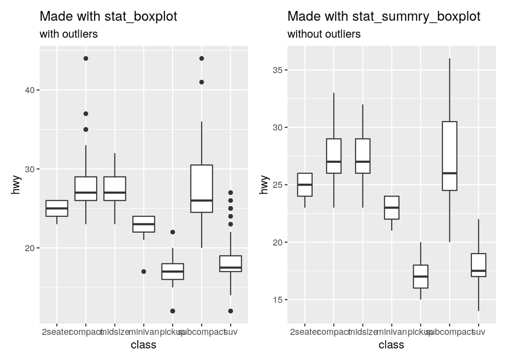

- *Note that the outliers are still there for further computations, but they are not plot.*

#### with extra information

If you want to add more information on your boxplots, you can use `stat_info_boxplot()` and `stat_point_boxplot()`.

- `stat_info_boxplot()` adds information about the number, mean, median or standard deviation of each boxplot. It allows to add a label and specify the size, color and vertical position of the label.

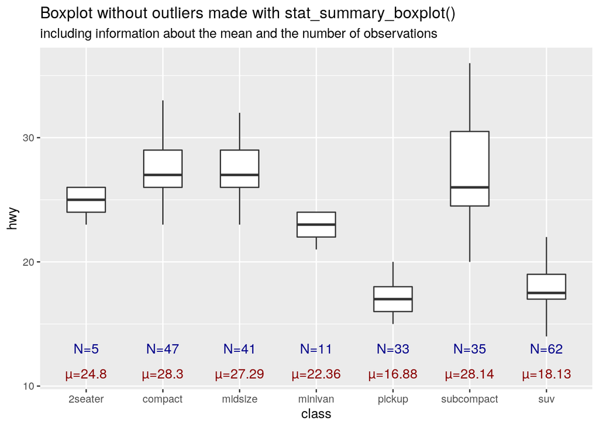

- `stat_point_boxplot()` draws a point at the mean, maximum, minimum or any quartile of each boxplot. It allows to specify color and size of the point.

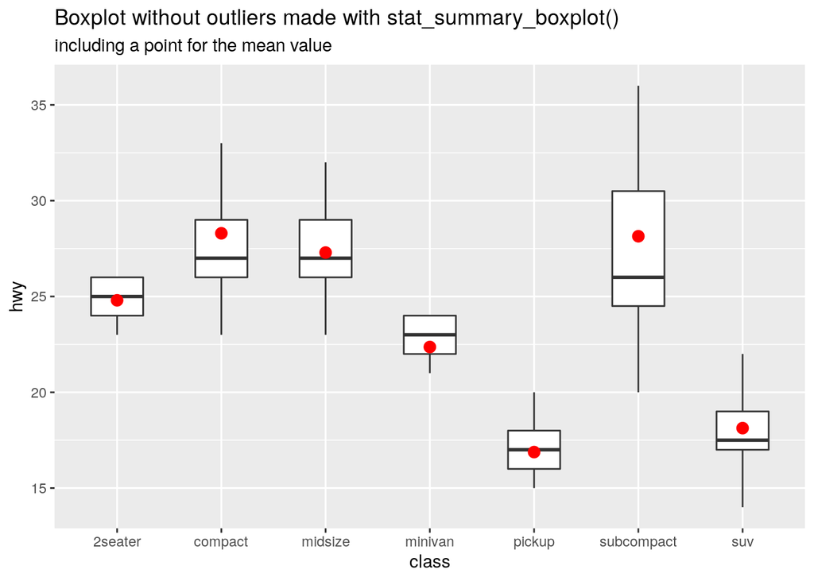

## Facets

Facets are nice features to make the plots better. However, if you want to paint the strips with different colors, you have to go through tricky workarounds. Hence, I created the functions `fill_strips_top()` and `fill_strips_right()` to fill the top and right facet strips, respectively.

They are not like a normal `ggplot2` function, so you cannot use `+` and you have to input the object directly into the function. Another drawback is that the resulting object cannot be modified by `theme()`, `scale_*_*()`, so all the required modifications have to be done before the coloring.

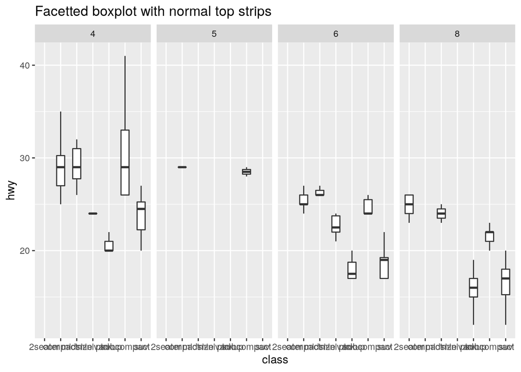

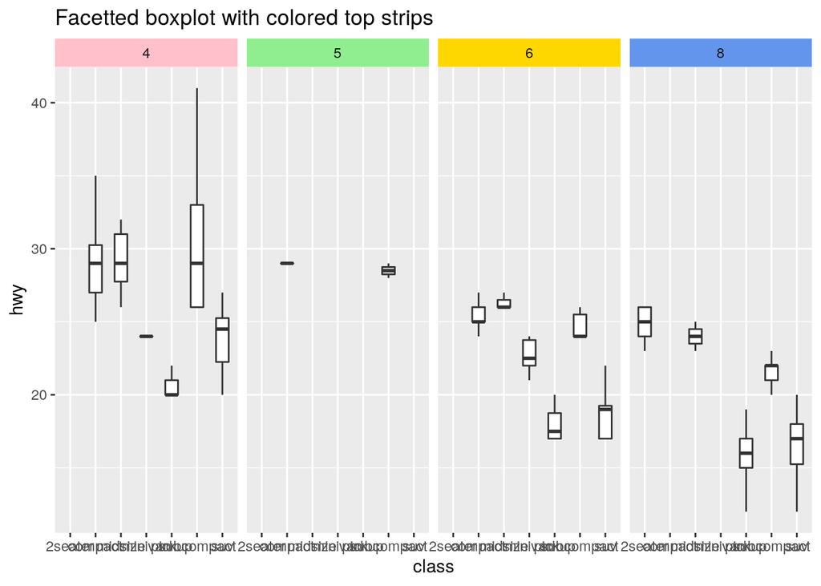

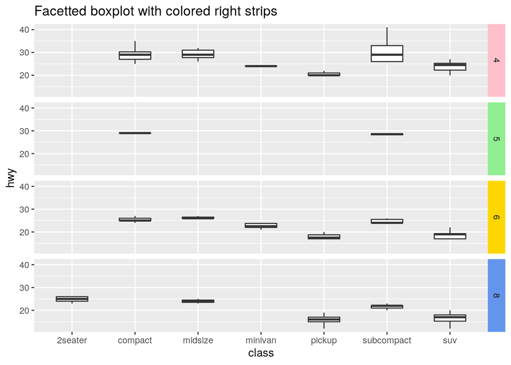

### Shaded Venn diagrams

Venn diagrams are useful to show intersections of different sets. Sometimes, the intersections, unions or other areas of the Venn are used to draw other plots. In these ocasions, you can draw a Venn diagram with shaded areas to specify what are you plotting.

For this cases, you can use `shaded_2d_venn()` and `shaded_3d_venn()` for 2D and 3D Venn diagrams respecitvely.

```
## polyclip 1.10-0 built from Clipper C++ version 6.4.0
```

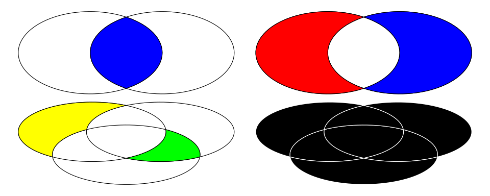

### Polygons

I have also add a `draw_polygon()` to draw several polygons and shapes. It allows to draw squares, circles, triangles, inverted-L-like polygons, hearts and diamonds.

It may not be very useful, but it is cool.

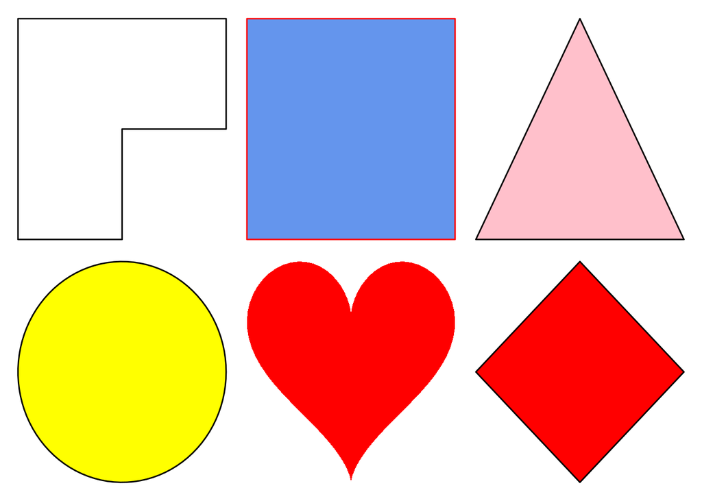

### Themes

`ggmitji` have several themes to customize almost everything in a ggplot.